```
## [1] 113937     21
```

```
## 'data.frame':    113937 obs. of  21 variables:
##  $ ListingNumber                     : int  193129 1209647 81716 658116 909464 1074836 750899 768193 1023355 1023355 ...
##  $ ListingCreationDate               : chr  "2007-08-26 19:09:29.263000000" "2014-02-27 08:28:07.900000000" "2007-01-05 15:00:47.090000000" "2012-10-22 11:02:35.010000000" ...
##  $ LoanStatus                        : chr  "Completed" "Current" "Completed" "Current" ...
##  $ ClosedDate                        : chr  "2009-08-14 00:00:00" NA "2009-12-17 00:00:00" NA ...
##  $ BorrowerAPR                       : num  0.165 0.12 0.283 0.125 0.246 ...
##  $ BorrowerRate                      : num  0.158 0.092 0.275 0.0974 0.2085 ...
##  $ ProsperScore                      : num  NA 7 NA 9 4 10 2 4 9 11 ...
##  $ ListingCategory..numeric.         : int  0 2 0 16 2 1 1 2 7 7 ...
##  $ BorrowerState                     : chr  "CO" "CO" "GA" "GA" ...
##  $ Occupation                        : chr  "Other" "Professional" "Other" "Skilled Labor" ...
##  $ EmploymentStatus                  : chr  "Self-employed" "Employed" "Not available" "Employed" ...
##  $ IsBorrowerHomeowner               : chr  "True" "False" "False" "True" ...
##  $ CreditScoreRangeLower             : int  640 680 480 800 680 740 680 700 820 820 ...
##  $ CreditScoreRangeUpper             : int  659 699 499 819 699 759 699 719 839 839 ...
##  $ CurrentDelinquencies              : int  2 0 1 4 0 0 0 0 0 0 ...
##  $ AmountDelinquent                  : num  472 0 NA 10056 0 ...
##  $ TradesNeverDelinquent..percentage.: num  0.81 1 NA 0.76 0.95 1 0.68 0.8 1 1 ...
##  $ IncomeRange                       : chr  "$25,000-49,999" "$50,000-74,999" "Not displayed" "$25,000-49,999" ...
##  $ LoanOriginalAmount                : int  9425 10000 3001 10000 15000 15000 3000 10000 10000 10000 ...
##  $ LoanOriginationDate               : chr  "2007-09-12 00:00:00" "2014-03-03 00:00:00" "2007-01-17 00:00:00" "2012-11-01 00:00:00" ...
##  $ LoanOriginationQuarter            : chr  "Q3 2007" "Q1 2014" "Q1 2007" "Q4 2012" ...
```

```
##  ListingNumber     ListingCreationDate  LoanStatus
##  Min.   :      4   Length:113937       Length:113937
##  1st Qu.: 400919   Class :character    Class :character
##  Median : 600554   Mode  :character    Mode  :character
##  Mean   : 627886
##  3rd Qu.: 892634
##  Max.   :1255725
##
##   ClosedDate         BorrowerAPR       BorrowerRate     ProsperScore
##  Length:113937      Min.   :0.00653   Min.   :0.0000   Min.   : 1.00
##  Class :character   1st Qu.:0.15629   1st Qu.:0.1340   1st Qu.: 4.00
##  Mode  :character   Median :0.20976   Median :0.1840   Median : 6.00
##                     Mean   :0.21883   Mean   :0.1928   Mean   : 5.95
##                     3rd Qu.:0.28381   3rd Qu.:0.2500   3rd Qu.: 8.00
##                     Max.   :0.51229   Max.   :0.4975   Max.   :11.00
##                     NA's   :25                         NA's   :29084
##  ListingCategory..numeric. BorrowerState       Occupation
##  Min.   : 0.000            Length:113937      Length:113937
##  1st Qu.: 1.000            Class :character   Class :character
##  Median : 1.000            Mode  :character   Mode  :character
##  Mean   : 2.774
##  3rd Qu.: 3.000
##  Max.   :20.000
##
##  EmploymentStatus   IsBorrowerHomeowner CreditScoreRangeLower
##  Length:113937      Length:113937       Min.   :  0.0
##  Class :character   Class :character    1st Qu.:660.0
##  Mode  :character   Mode  :character    Median :680.0
##                                         Mean   :685.6
##                                         3rd Qu.:720.0
##                                         Max.   :880.0
##                                         NA's   :591
##  CreditScoreRangeUpper CurrentDelinquencies AmountDelinquent
##  Min.   : 19.0         Min.   : 0.0000      Min.   :     0.0
##  1st Qu.:679.0         1st Qu.: 0.0000      1st Qu.:     0.0
##  Median :699.0         Median : 0.0000      Median :     0.0
##  Mean   :704.6         Mean   : 0.5921      Mean   :   984.5
##  3rd Qu.:739.0         3rd Qu.: 0.0000      3rd Qu.:     0.0
##  Max.   :899.0         Max.   :83.0000      Max.   :463881.0
##  NA's   :591           NA's   :697          NA's   :7622
##  TradesNeverDelinquent..percentage. IncomeRange        LoanOriginalAmount
##  Min.   :0.000                      Length:113937      Min.   : 1000
##  1st Qu.:0.820                      Class :character   1st Qu.: 4000
##  Median :0.940                      Mode  :character   Median : 6500
##  Mean   :0.886                                         Mean   : 8337
##  3rd Qu.:1.000                                         3rd Qu.:12000
##  Max.   :1.000                                         Max.   :35000
##  NA's   :7544
##  LoanOriginationDate LoanOriginationQuarter
##  Length:113937       Length:113937
##  Class :character    Class :character
##  Mode  :character    Mode  :character
##
##
##
##
```

```
##  ListingNumber     ListingCreationDate   LoanStatus
##  Min.   :      4   Min.   :2005-11-09   Length:113937
##  1st Qu.: 400919   1st Qu.:2008-09-19   Class :character
##  Median : 600554   Median :2012-06-16   Mode  :character
##  Mean   : 627886   Mean   :2011-07-08
##  3rd Qu.: 892634   3rd Qu.:2013-09-09
##  Max.   :1255725   Max.   :2014-03-10
##
##    ClosedDate          BorrowerAPR       BorrowerRate     ProsperScore
##  Min.   :2005-11-25   Min.   :0.00653   Min.   :0.0000   Min.   : 1.00
##  1st Qu.:2009-07-14   1st Qu.:0.15629   1st Qu.:0.1340   1st Qu.: 4.00
##  Median :2011-04-05   Median :0.20976   Median :0.1840   Median : 6.00
##  Mean   :2011-03-07   Mean   :0.21883   Mean   :0.1928   Mean   : 5.95
##  3rd Qu.:2013-01-30   3rd Qu.:0.28381   3rd Qu.:0.2500   3rd Qu.: 8.00
##  Max.   :2014-03-10   Max.   :0.51229   Max.   :0.4975   Max.   :11.00
##  NA's   :58848        NA's   :25                         NA's   :29084
##  ListingCategory..numeric. BorrowerState       Occupation
##  Min.   : 0.000            Length:113937      Length:113937
##  1st Qu.: 1.000            Class :character   Class :character
##  Median : 1.000            Mode  :character   Mode  :character
##  Mean   : 2.774
##  3rd Qu.: 3.000
##  Max.   :20.000
##
##  EmploymentStatus   IsBorrowerHomeowner CreditScoreRangeLower
##  Length:113937      Length:113937       Min.   :  0.0
##  Class :character   Class :character    1st Qu.:660.0
##  Mode  :character   Mode  :character    Median :680.0
##                                         Mean   :685.6
##                                         3rd Qu.:720.0
##                                         Max.   :880.0
##                                         NA's   :591
##  CreditScoreRangeUpper CurrentDelinquencies AmountDelinquent
##  Min.   : 19.0         Min.   : 0.0000      Min.   :     0.0
##  1st Qu.:679.0         1st Qu.: 0.0000      1st Qu.:     0.0
##  Median :699.0         Median : 0.0000      Median :     0.0
##  Mean   :704.6         Mean   : 0.5921      Mean   :   984.5
##  3rd Qu.:739.0         3rd Qu.: 0.0000      3rd Qu.:     0.0
##  Max.   :899.0         Max.   :83.0000      Max.   :463881.0
##  NA's   :591           NA's   :697          NA's   :7622
##  TradesNeverDelinquent..percentage. IncomeRange        LoanOriginalAmount
##  Min.   :0.000                      Length:113937      Min.   : 1000
##  1st Qu.:0.820                      Class :character   1st Qu.: 4000
##  Median :0.940                      Mode  :character   Median : 6500
##  Mean   :0.886                                         Mean   : 8337
##  3rd Qu.:1.000                                         3rd Qu.:12000
##  Max.   :1.000                                         Max.   :35000
##  NA's   :7544
##  LoanOriginationDate  LoanOriginationQuarter
##  Min.   :2005-11-15   Length:113937
##  1st Qu.:2008-10-02   Class :character
##  Median :2012-06-26   Mode  :character
##  Mean   :2011-07-21
##  3rd Qu.:2013-09-18
##  Max.   :2014-03-12
##
```

# 单变量绘图选择

```
##
##   9.5 369.5 429.5 449.5 469.5 489.5 509.5 529.5 549.5 569.5 589.5 609.5
##   133     1     5    36   141   346   554  1593  1474  1357  1125  3602
## 629.5 649.5 669.5 689.5 709.5 729.5 749.5 769.5 789.5 809.5 829.5 849.5
##  4172 12199 16366 16492 15471 12923  9267  6606  4624  2644  1409   567
## 869.5 889.5
##   212    27
```

[figure not shown]

```
##
##     0  0.03  0.05  0.06  0.07  0.08  0.09   0.1  0.11  0.12  0.13  0.14
##    51     1     8     3    11     8     6     9    18    16    10    18
##  0.15  0.16  0.17  0.18  0.19   0.2  0.21  0.22  0.23  0.24  0.25  0.26
##    13    40    10    24     5    47    22    34    29     7    93    36
##  0.27  0.28  0.29   0.3  0.31  0.32  0.33  0.34  0.35  0.36  0.37  0.38
##    37    46    23    61    23     5   197    20    67    72    82    81
##  0.39   0.4  0.41  0.42  0.43  0.44  0.45  0.46  0.47  0.48  0.49   0.5
##    24   197    92   158    75   127   127   161   133    52     1   722
##  0.51  0.52  0.53  0.54  0.55  0.56  0.57  0.58  0.59   0.6  0.61  0.62
##    73   259   250   226   303   210   484   363   132   654   478   537
##  0.63  0.64  0.65  0.66  0.67  0.68  0.69   0.7  0.71  0.72  0.73  0.74
##   487   587   487  1469   236   861   653  1086   913  1080   989   358
##  0.75  0.76  0.77  0.78  0.79   0.8  0.81  0.82  0.83  0.84  0.85  0.86
##  1888  1377  1211  1292   504  2202  1395  1171  1709  1563  2086  1679
##  0.87  0.88  0.89   0.9  0.91  0.92  0.93  0.94  0.95  0.96  0.97  0.98
##  1768  2507  1110  3171  1960  2880  2834  3051  3755  4245  2609   443
##  0.99     1
##     1 41705
```

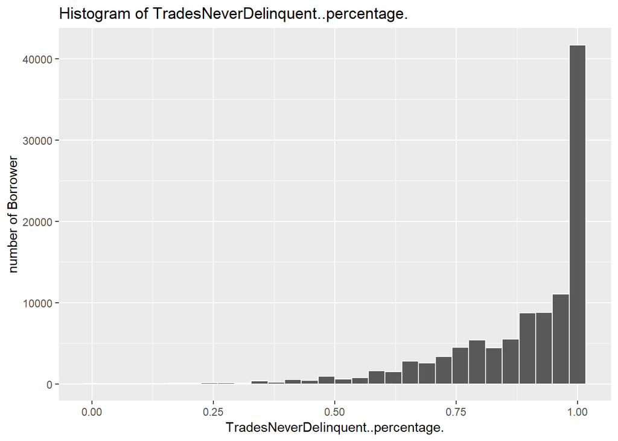

通过接待人的信用得分评估的直方图我们可以看到,用户的信用得分基本符合正态分布 通过对借贷人交易拖欠款的直方图我们可以发现大多数的用户交易都没有拖欠，只有少部分的用户存在拖欠行为，说明他们的信用很好

```
##
##      Employed     Full-time     Part-time Self-employed  Not employed
##         67322         26355          1088          6134           835
##       Retired
##           795
```

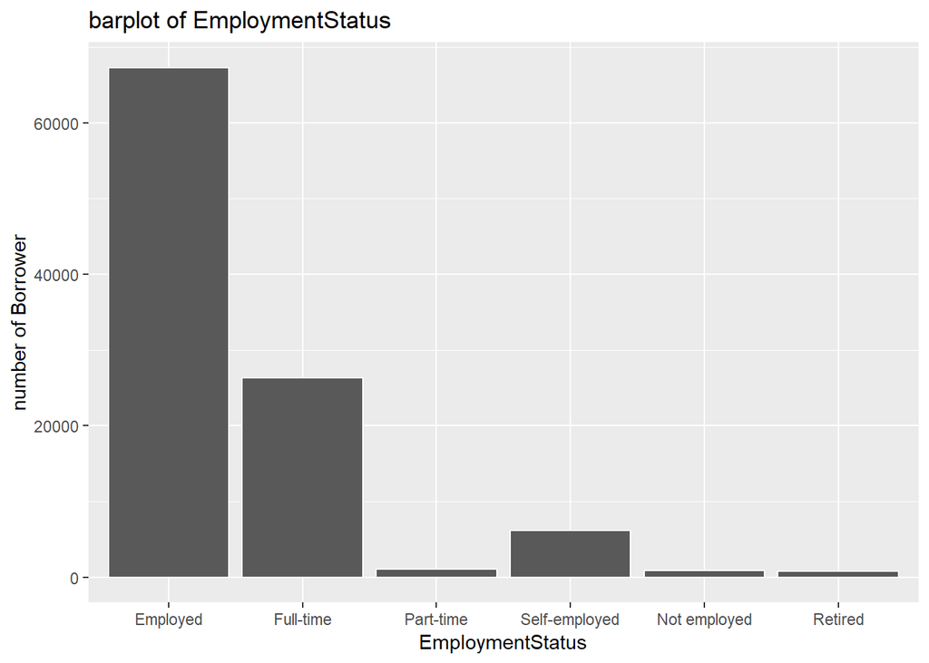

```
##
## False  True
## 56459 57478
```

```
##
##  Not displayed   Not employed             $0      $1-24,999 $25,000-49,999
##           7741            806            621           7274          32192
## $50,000-74,999 $75,000-99,999      $100,000+
##          31050          16916          17337
```

```
## data$IsBorrowerHomeowner: False
##  Not displayed   Not employed             $0      $1-24,999 $25,000-49,999
##           5122            600            347           5751          19985
## $50,000-74,999 $75,000-99,999      $100,000+
##          13929           6025           4700
## --------------------------------------------------------
## data$IsBorrowerHomeowner: True
##  Not displayed   Not employed             $0      $1-24,999 $25,000-49,999
##           2619            206            274           1523          12207
## $50,000-74,999 $75,000-99,999      $100,000+
##          17121          10891          12637
```

[figure not shown]

在事先统计中我们发现有部分人的职业状态显示为NA，在对数据进行筛选后,通过对贷款人工作状态的柱状图，我们可以看到绝大部分用户都是“Employed”状态，其次是“Full-time”。 通过分析用户的收入区间和是否有房产的统计，我们可以发现在相对高收入的人群(>$50,000)中，有房子的比率是大于五房子的比率的。 通过分析用户的收入区间分布，我发现大部分贷款用户为中收入水平[$50,000-74,999]和[$25,000-49,999]，其次则是高收入水平。

```
##
##              Completed FinalPaymentInProgress                Current
##                  38074                    205                  56576
##   Past Due (1-15 days)  Past Due (16-30 days)  Past Due (31-60 days)
##                    806                    265                    363
##  Past Due (61-90 days) Past Due (91-120 days)   Past Due (>120 days)
##                    313                    304                     16
##             Chargedoff              Defaulted              Cancelled
##                  11992                   5018                      5
```

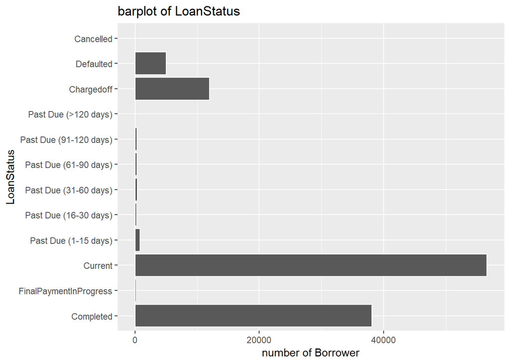

```
##  2005  2006  2007  2008  2009  2010  2011  2012  2013  2014
##    22  5906 11460 11552  2047  5652 11228 19553 34345 12172
```

```
## data$LoanYear: 2005
##    Min. 1st Qu.  Median    Mean 3rd Qu.    Max.    NA's
##      NA      NA      NA     NaN      NA      NA      22
## --------------------------------------------------------
## data$LoanYear: 2006
##    Min. 1st Qu.  Median    Mean 3rd Qu.    Max.    NA's
## 0.00653 0.14709 0.19884 0.20061 0.25757 0.51229       3
## --------------------------------------------------------
## data$LoanYear: 2007
##    Min. 1st Qu.  Median    Mean 3rd Qu.    Max.
## 0.00653 0.13501 0.17722 0.18593 0.23662 0.37036
## --------------------------------------------------------
## data$LoanYear: 2008
##    Min. 1st Qu.  Median    Mean 3rd Qu.    Max.
## 0.01315 0.13625 0.17791 0.20363 0.26214 0.41355
## --------------------------------------------------------
## data$LoanYear: 2009
##    Min. 1st Qu.  Median    Mean 3rd Qu.    Max.
## 0.05636 0.12511 0.21122 0.21594 0.28777 0.39951
## --------------------------------------------------------
## data$LoanYear: 2010
##    Min. 1st Qu.  Median    Mean 3rd Qu.    Max.
## 0.04583 0.13068 0.24999 0.23899 0.33097 0.42395
## --------------------------------------------------------
## data$LoanYear: 2011
##    Min. 1st Qu.  Median    Mean 3rd Qu.    Max.
## 0.05927 0.19108 0.29486 0.26230 0.34731 0.38723
## --------------------------------------------------------
## data$LoanYear: 2012
##    Min. 1st Qu.  Median    Mean 3rd Qu.    Max.
## 0.06587 0.18637 0.25781 0.25315 0.33553 0.35840
## --------------------------------------------------------
## data$LoanYear: 2013
##    Min. 1st Qu.  Median    Mean 3rd Qu.    Max.
## 0.06106 0.16732 0.20933 0.21395 0.25781 0.35797
## --------------------------------------------------------
## data$LoanYear: 2014
##    Min. 1st Qu.  Median    Mean 3rd Qu.    Max.
## 0.06726 0.14206 0.17710 0.18272 0.21648 0.34630
```

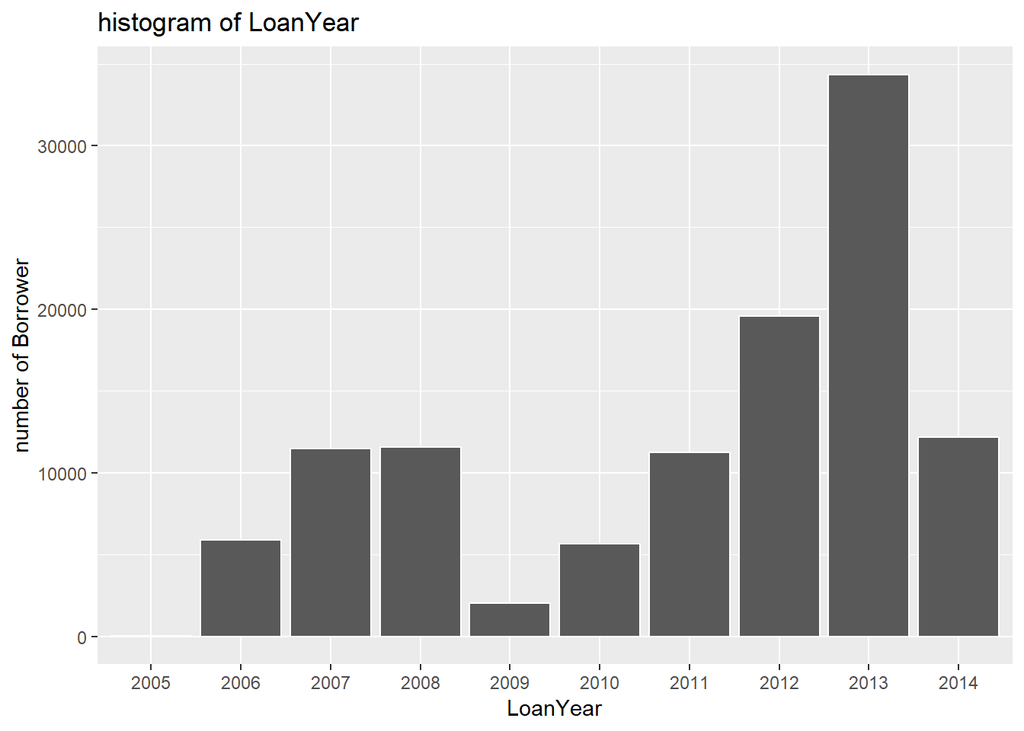

[figure not shown]

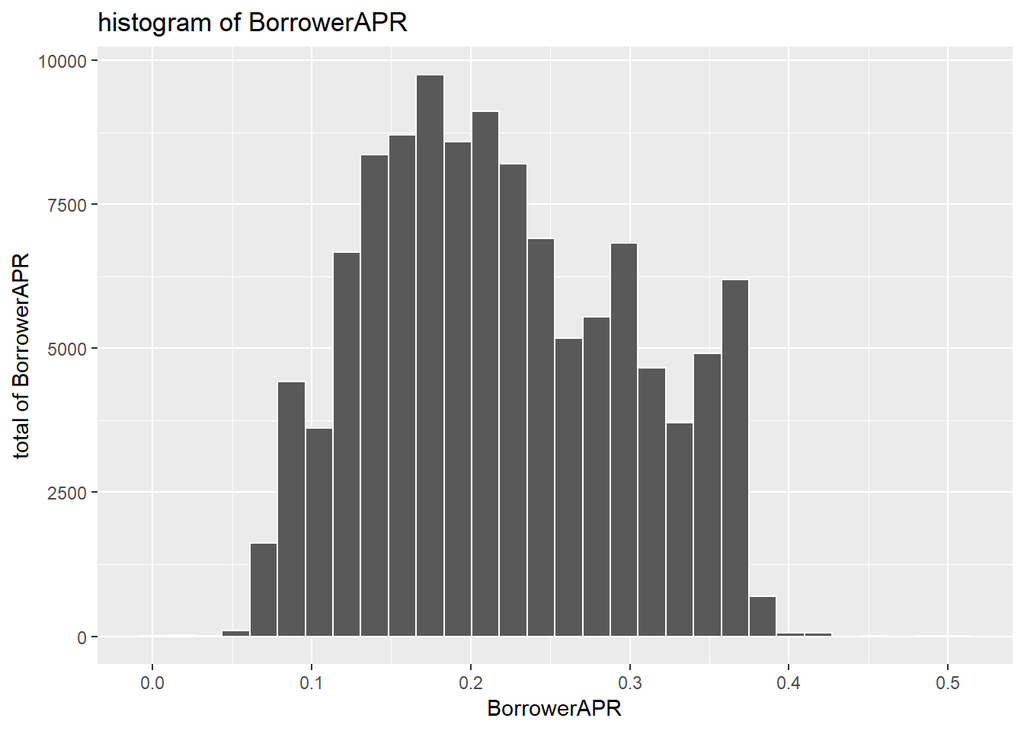

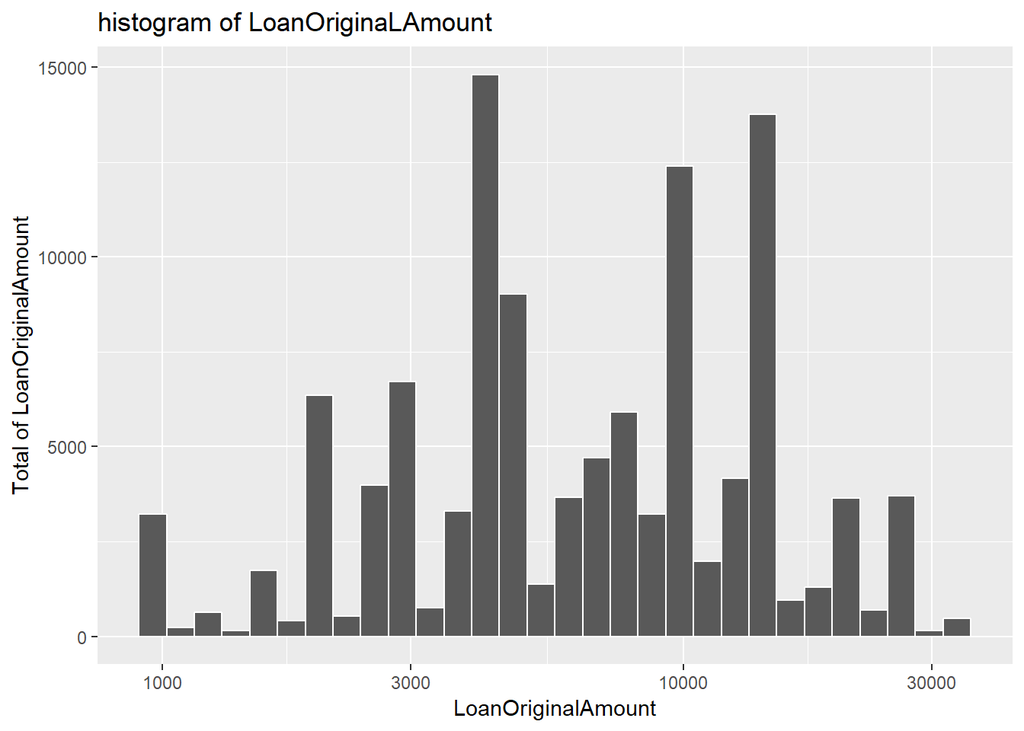

### 你的数据集内感兴趣的主要特性有哪些？

“CreditScore” :他衡量了我们的所有用户的信用程度，让我们更好的评估贷款的风险 “BorrowAPR” :我想通过这来分析贷款年利率的变化，看是否与年份以及用户的个人信用情 况有关。 “LoanStaus” :我想分析不同的贷款的还款状况，看是否信用评分高低和贷款原因与这有关 ### 你认为数据集内哪些其他特征可以帮助你探索兴趣特点？ “IncomeRANGE” :这个更加直观地能让我们了解用户的收入，并且我想借此分析在贷款的人 群中的收入高低情况。 “TradesNeverDelinquent..percentage.” :我想他也能让我们更加全面的评估用户在这 笔贷款中还款的几率。 “LoanYear” :我认为可以通过这个来作为分类依据帮组我们分析贷款年利率的变化。 “ListingCategory..numeric”:这也能帮助我们分析用户贷款的金额和还款的情况。 ### 根据数据集内已有变量，你是否创建了任何新变量？ “LoanYear”,“LoanMonth”,“ListingCategory”,“CreditScore” ### 在已经探究的特性中，是否存在任何异常分布？你是否对数据进行一些操作，如清洁、调整或改变数据的形式？如果是，你为什么会这样做？ 在已经探究的特性中，我并未发现异常的分布。 我已经数据进行的操作有:将“ListingCreationDate”,“LoanOriginationDate”, “ClosedDated”转化为Datetime格式，因为这样的格式跟便于我们进行统计 对“LoanOriginationQuarter”,“LoanStatus”,“IncomeRange”,“EmploymentStatus”,“ListingCategory”等离散特征的顺序进行了调整，因为这样能让我们在后面的可视化中更加直观的进行观察。

# 双变量绘图选择

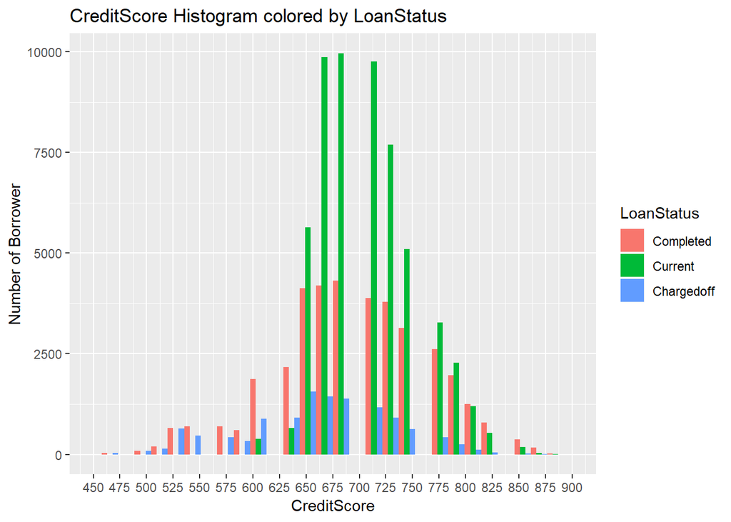

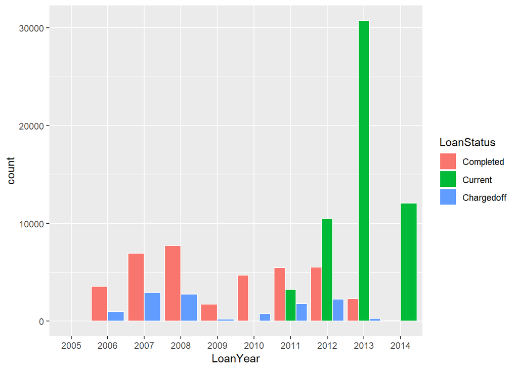

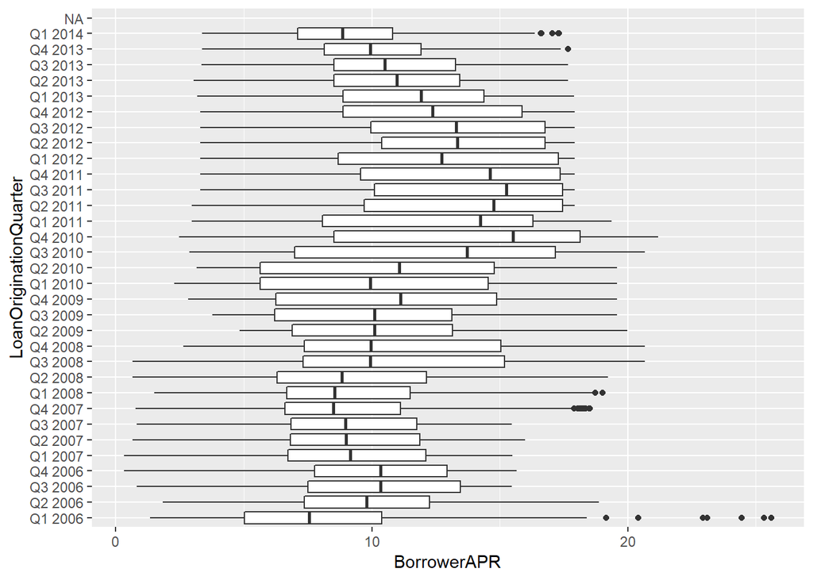

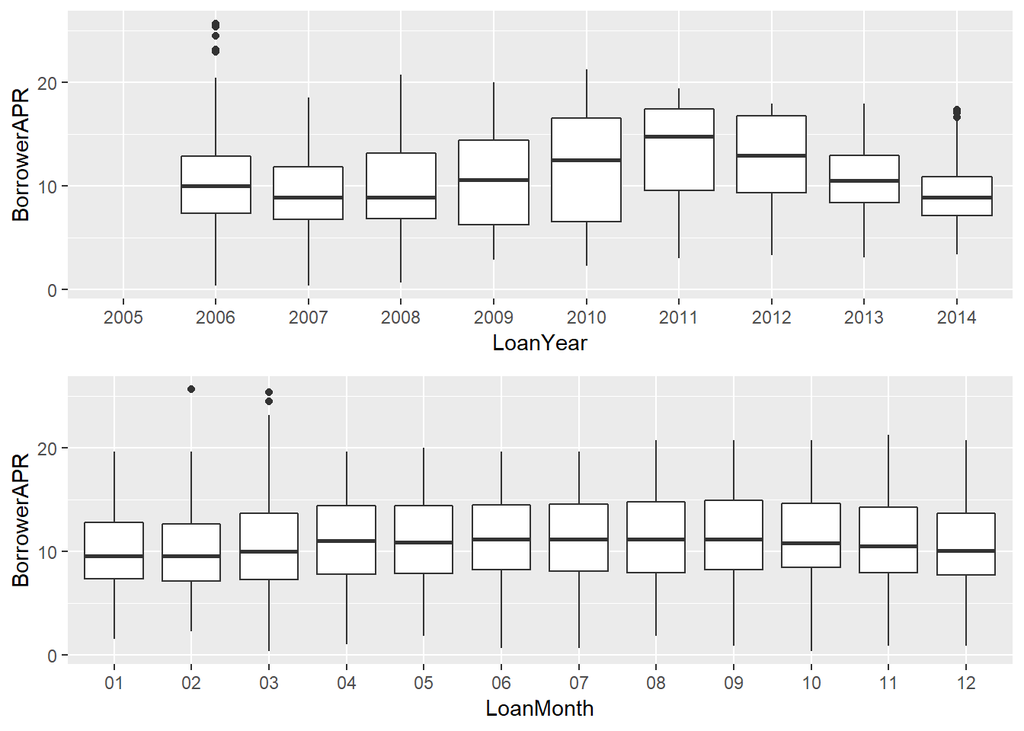

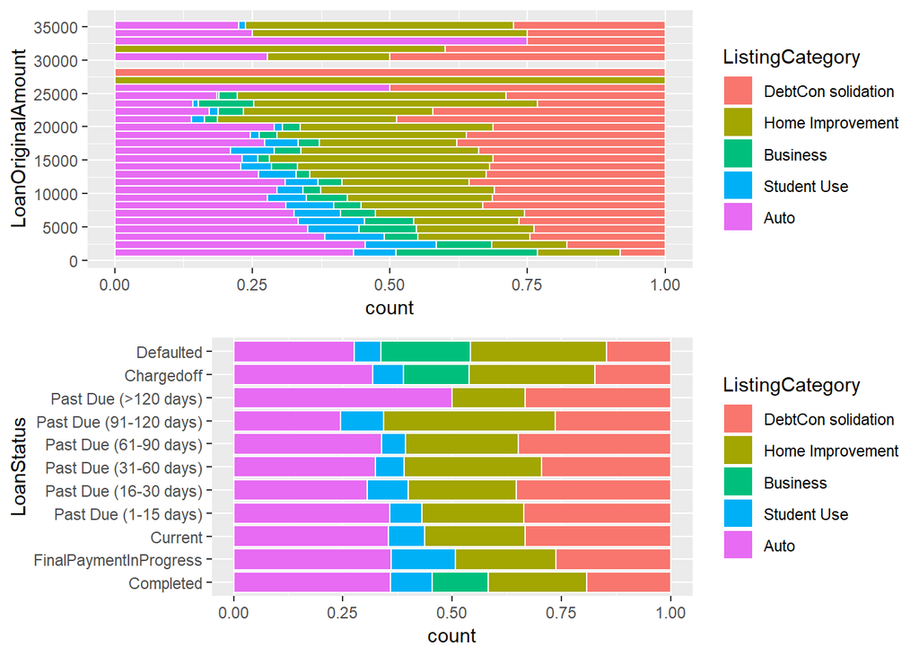

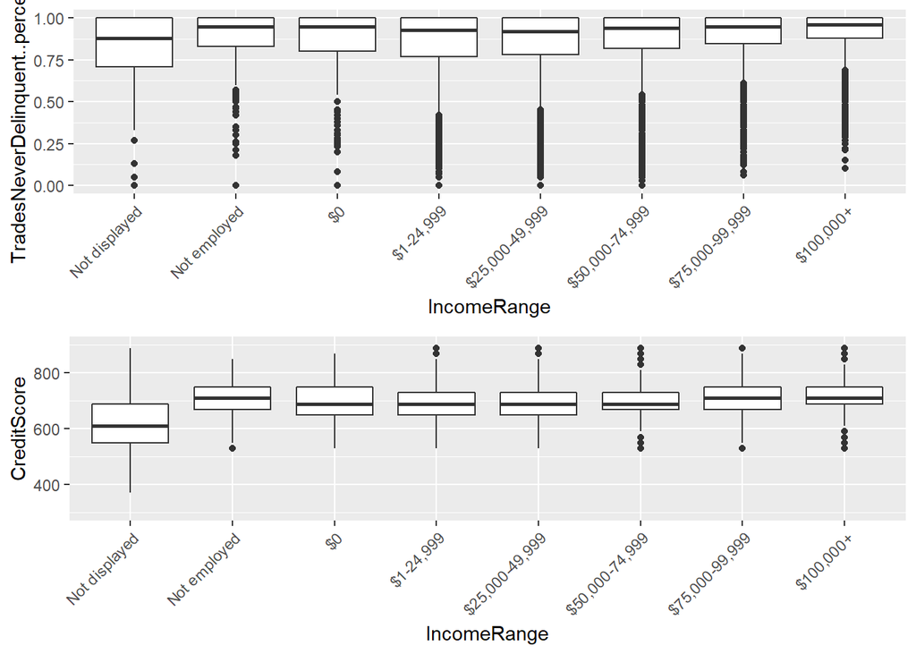

```
##
##  Pearson's product-moment correlation
##
## data:  data$CreditScore and data$TradesNeverDelinquent..percentage.
## t = 173.16, df = 106390, p-value < 2.2e-16
## alternative hypothesis: true correlation is not equal to 0
## 95 percent confidence interval:
##  0.4641980 0.4735735
## sample estimates:
##      cor
## 0.468899
```

```
##
##  Pearson's product-moment correlation
##
## data:  data$CreditScore and data$BorrowerAPR
## t = -160.21, df = 113340, p-value < 2.2e-16
## alternative hypothesis: true correlation is not equal to 0
## 95 percent confidence interval:
##  -0.4344422 -0.4249487
## sample estimates:
##        cor
## -0.4297073
```

在信用评分和用户交易拖欠的比例的相关性分析中，我发现两者有着正相关的关系，但这关系并不强

# 双变量分析

### 探讨你在这部分探究中观察到的一些关系。这些感兴趣的特性与数据集内其他特性有什么区别？

我的探究分析已经在上面可视化的时候随图展示出来了

### 你是否观察到主要特性与其他特性之间的有趣关系？

# 多变量绘图选择

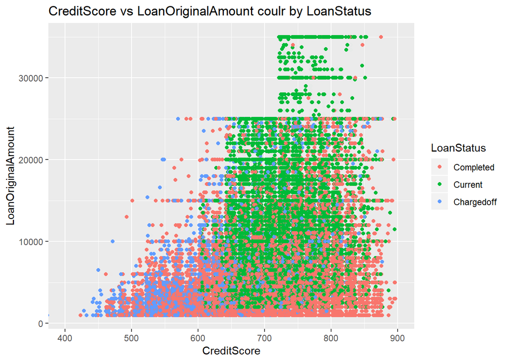

在上面信用得分与贷款状态的基础上我们加入了贷款数额仪器分析，我们发现贷款数额小的贷款基本都是“Completed”状态，然而出人意料的是处于“current”状态中的最多的电反而是信用得分较高的用户(650,820),此外我们还发现这个区间的用户往往倾向与借额度更高的贷款。

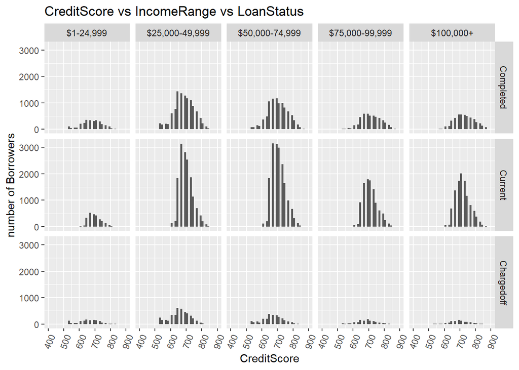

首先我们发现用户的数量分布在不同分类的统计下都基本符合正态分布,我发现用户贷款情况主要分布在“Completed”和“Current”中,同时在收入区间为25,000-49,999;50,000-74,999;75,000-99,999;100,000+这几个区间中.

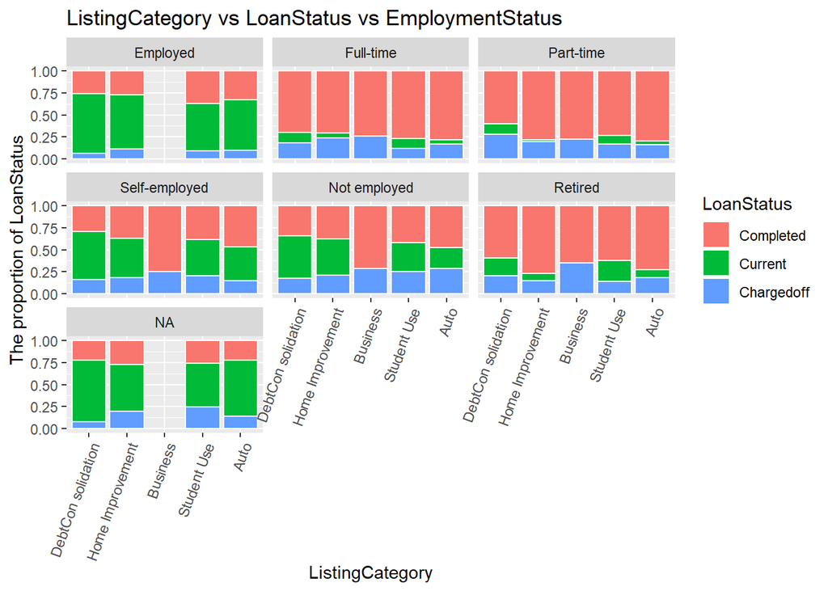

我发现职业为“Full-time”和“Part-time”和“Retired”的用户的贷款总的来说都按时还款,然而还有一部分的贷款处于“Chargedoff”阶段； 而职业为“Employed”的用户更多的借贷都处于“Current”的状态,可能因为他们的工资的原因； 而“Self-employed”的用户因“Business”原因借的贷款很多都已经按时还款。 # 多变量分析

### 探讨你在这部分探究中观察到的一些关系。通过观察感兴趣的特性，是否存在相互促进的特性？

这个我已经在上面可视化的过程中随图展示了分析 ### 这些特性之间是否存在有趣或惊人的联系呢？ 我发现用户的信用评分往往和他们的职业相关，并且他们按时还款的可能性会更高 ### 选项：你是否创建过数据集的任何模型？讨论你模型的优缺点。 我没有对数据进行建模,在这个数据集中更多是数据是离散形式的数据，因此我更多是对他们进行定性的分析 —— # 定稿图与总结

### 绘图一

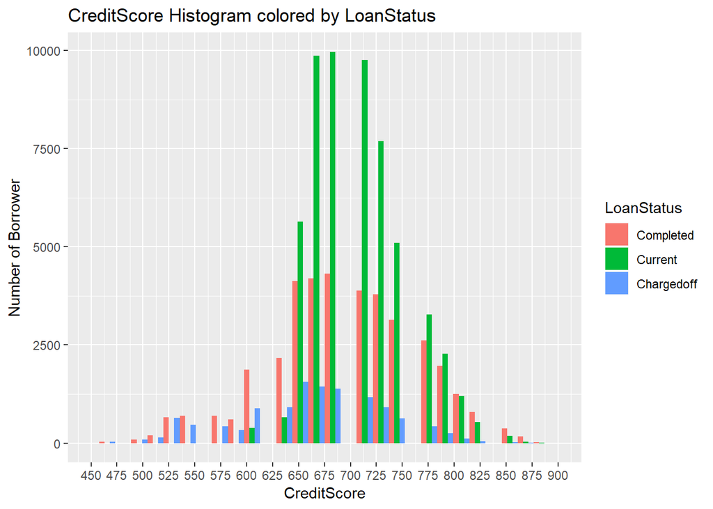

### 描述一

在这个直方图我们能够发现一个很有趣的规律那就是用户的信用评估和他们的还款情况并不是严格意义上的正相关关系:信用评分在(600,700)之间的用户按时还款的纪律反而随着评分的上升而下降,此后(650,900)区间的用户按时还款的几率与他们的信用评分呈现正相关关系,而信用评分较低的用户他们有很大一部分的人的贷款都是chargedoff.

### 绘图二

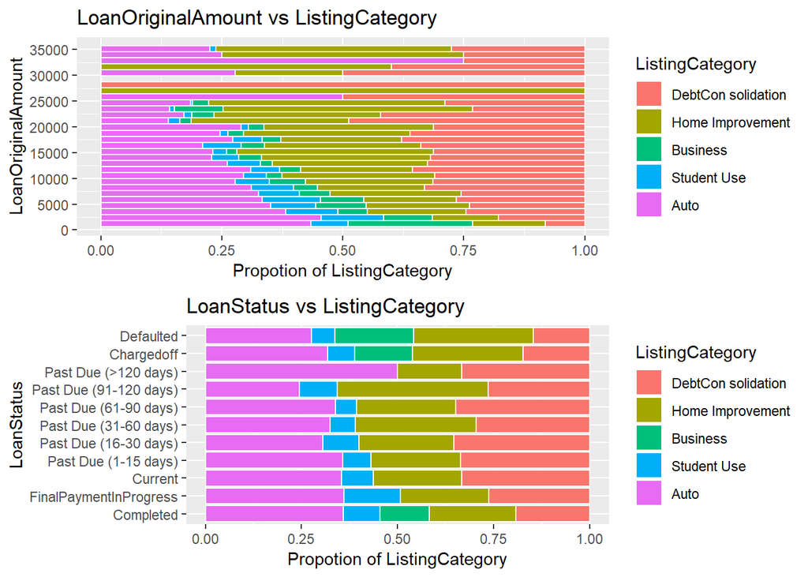

### 绘图三

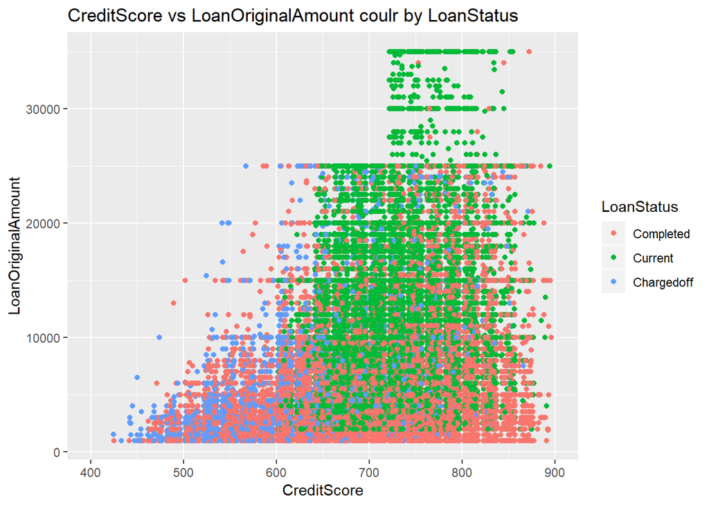

### 描述三

通过这个(三变量)的散点图，我们可以发现用户的信用评分越高,他们还款的几率也越高,但是他们打款的数额往往并不是最高的, 信用得分在(700,850)之间的用户往往每次贷款的额度会更高,但是他们更多的贷款的状态还处于“Current” ——

# 反思

这次的EDA项目中我选择的数据集是互联网金融的贷款数据,在这个数据集中有许多的变量,并且他们都有着不同的类型和不同的意义,我在了解了众多变量后筛选出了自己认为感兴趣的变量,大致分为介绍用户信用的,介绍用户具体信息的,介绍每笔贷款具体信息的变量,并且对其中的一些变量做了调整,也创建了新的变量来进行探索.在数据可视化的过程中我对自己感兴趣的变量都做了各种不同的尝试以及优化,但是美中不足的地方是我感觉我所选择的变量更多的是分类变量而不是数值变量,这也使得我在探索的可视化图形中有所限制。此外我所选择的数据也不太方便我从建模预测的角度进行思考,我觉得课后我可以尝试不同的角度来对这个数据集进行处理和探索.